# Calculating Diversity

## Measures of Diversity

> - Species richness
>   - Number of species actually present
> - Simpson diversity
>   - Chance of two individuals being the same species
> - Shannon entropy
>   - Surprise in seeing next individual
> - Berger-Parker
>   - Evenness / Dominance of most abundant species

## Measures of Diversity

$$D_q = \left( \sum_{i \in \{1 \dots N_S,
p_i \neq 0\}} p_i^q \right)^{\frac{1}{1-q}}$$

Covers all of these measures.

## Measures of Diversity

- Species richness
  - Number of species actually present
- Simpson diversity
  - Chance of two individuals being the same species
- Shannon entropy
  - Surprise in seeing next individual
- Berger-Parker
  - Evenness / Dominance of most abundant species

## Measures of Diversity

- Species richness
  - $D_0$
- Simpson diversity
  - $\frac{1}{D_2}$
- Shannon entropy
  - $log(D_1)$
- Berger-Parker
  - $\frac{1}{D_\infty}$

## Measures of Diversity

- Species richness
  - $D_0$
- Shannon entropy
  - $log(D_1)$
- Simpson diversity
  - $\frac{1}{D_2}$
- Berger-Parker
  - $\frac{1}{D_\infty}$

## Measures of Diversity

- $D_0$
  - Species richness
- $log(D_1)$
  - Shannon entropy
- $\frac{1}{D_2}$
  - Simpson diversity
- $\frac{1}{D_\infty}$
  - Berger-Parker

## Measures of Diversity

- $D_0$
  - Species richness
- $D_1$
  - exp(Shannon entropy)
- $D_2$
  - 1 / Simpson diversity
- $D_\infty$
  - 1 / Berger-Parker

## Diversity profiles

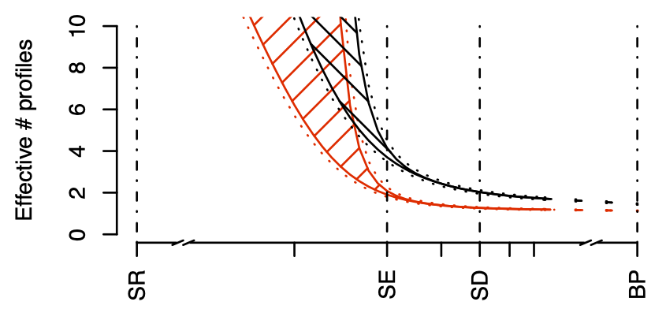

## Useful R

- `sort()` to sort a vector into ascending order
- `rep()`
- `barplot()`
- `rmultinom()` to generate multinomially distributed samples
- `Inf` is how we say infinity in R
- `lines()`

## Deadlines

- Edits to GitHub repos – as soon as possible, but:
  - Practical Series 2-4: Wednesday 5th January
    - unless you ask for an extension
- Project submission
  - by Tuesday 25th January, 1pm
- Marks returned by Tuesday 15th February

## Package assessment

- Does the package work (installs, docs, functions, demos and dependencies)?

```r
    devtools::install_github("SBOHVM/pkgname")
    library(pkgname)
    library(help="pkgname")
    demo(package="pkgname")
    ?pkgname
```

- Can I generate reports from your demos, and how do they look?
- Is the code well structured and with clear variable names and comments?
- Is the documentation correct (for package, functions, and text in reports)?
- Does the code work correctly?